# Github Quick Start! - For window users

by 오태환

[figure not shown]

## 1. 깃허브 왜 쓰는거에요?

- 협업하기 쉽다!
  - 코드를 공유하기 쉽다
  - 코드의 충돌을 방지할 수 있다
- 내가 한 것 들의 기록을 남길 수 있다!
  - [잔디를 심어보자](https://github.com/dhxoghks95)
  - [데이터 사이언스쪽 취준을 할 때 포트폴리오로 쓰인다!](https://ohdata.netlify.app/about/)

## 2. 그럼 어떻게 해야하죠?

- [Git Bash 다운받기](https://gitforwindows.org/)

다 해오셨을거라 믿습니다!

## a. 초기 설정하기

[figure not shown]

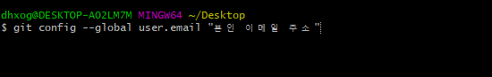

바탕화면에서 마우스 우클릭 후 git bash here를 눌러주세요. 그러면 git bash가 나옵니다 git bash 창에

git config – global user.name “본인 이름”

git config – global user.email “본인 이메일 주소”

를 치고 엔터를 눌러주세요!

## b. 이번 여름 세션 동안 쓸 폴더 만들기

저는 esc_summer라는 폴더를 만들었습니다

## 주의사항!

- 폴더 이름은 영어로 해주세요
- 띄어쓰기 대신 _를 써주세요

## c. 만든 폴더에서 gitbash 열기

[figure not shown]

만든 폴더에 들어가 마우스 우클릭 후 gitbash here를 눌러봅시다

## d. Github Repository Fork뜨기

[figure not shown]

초대받은 ESC github repository 에 들어가 FORK를 클릭합시다

[figure not shown]

그럼 이렇게 본인 깃허브에 같은 repository가 들어오게 됩니다!

## e. Github Repository를 Local로 불러오기

[figure not shown]

다시 ESC github repository에 들어가서, Code를 누른 후 해당 레포의 url을 복사합시다

그리고 다시 아까 열어놓은 Git Bash로 가봅시다.

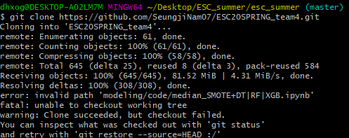

git clone 복사한 url 붙여넣기

를 입력하고 엔터를 누르면 위와 같이 다운로드가 되면서

[figure not shown]

Git Bash를 연 폴더에 우리가 복사한 url의 repository가 생깁니다!

## f. 자기 repository 주소를 remote 하기

아까 포크 뜬 본인 repository에 가서 위에 한 것과 같이 url을 복사합시다.

그리고 다시 Git Bash에 돌아가서

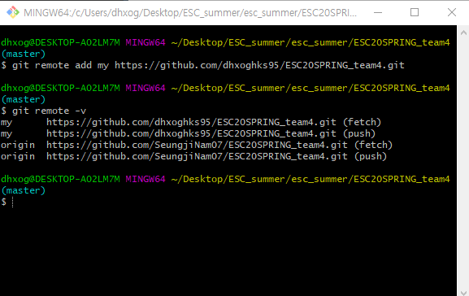

git remote add 리모트명 아까복사한url

을 치면 remote가 만들어지고

git remote -v

를 치면 본인 repo의 remote, 그리고 origin 이란 이름의 ESC repo 이렇게 두 개의 remote가 존재하는걸 확인할 수 있습니다

## g. Git Pull (ESC repo)

자 이제부터 중요합니다.

git을 쓸 때 반드시 git pull을 하고 진행하셔야 합니다! 업데이트를 하고 시작해야 다른 팀원들과의 충돌을 막을 수 있겠죠? 기껏 해놓은 다른 팀원의 파일이 없어질 수도 있습니다 ㅠㅠ

## 주의사항

- 본인 repo의 url이 아니라, esc repo의 url의 remote로 pull을 해주셔야 합니다. 그래야 다른 사람의 코드도 업데이트 할 수 있겠죠?

아까 git remote -v를 눌렀을 때 확인할 수 있듯, ESC repo의 remote 명은 origin 입니다.

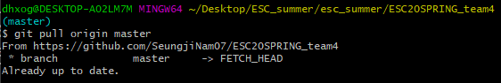

즉 위와 같이 git pull origin master (여기서 master는 branch의 이름인데, branch까지 설명하기엔 시간이 길어져서 궁금하신 분은 google에 검색해보세요!)

를 치고 엔터를 누르면 폴더가 업데이트 됩니다. 저와 같이 Already Up to date가 뜨면 업데이트할 것이 없다는 뜻입니다

## h. git add와 git commit

자 이제 본인이 쓴 코드파일(.R 혹은 .ipynb가 되겠죠?)을 본인이 넣고싶은 폴더에 넣고

아까 연 Git Bash에

[figure not shown]

git add .

을 쓰고 엔터를 누릅니다. 이렇게 하면 본인이 추가한 파일이 로컬에 업로드 됩니다!

하지만 git add .은 모든 코드를 업로드 하는 방식이기 때문에 구분을 할 수 없어 추천드리는 방법은 아닙니다. 하지만 여러 개의 파일을 한 번에 업로드 하고 싶으신 분은 이렇게 하면 돼요

그렇다면 개별 파일을 add 하기 위해선 어떻게 해야할까요?

git add 경로/파일명

을 쓰시면 됩니다.

자 이제 commit을 해봅시다

[figure not shown]

git commit -m“커밋 메시지”

를 치고 엔터를 누르면 됩니다. 이 때 쓴 메시지가 어디에 출력되냐면

[figure not shown]

이렇게 파일명 옆에 메시지가 뜨게 됩니다

## i. git push

자 이제 내 repo에 수정한 부분을 반영해봅시다.

[figure not shown]

git push 아까써놓은내repo의remote명 master

이렇게 쓰고 엔터를 누르면 이제 업로드가 됩니다!

## 주의사항

- esc repo가 아니라 본인 repo로 push 해주세요!

자 이제 본인 repo에 수정 사항들이 업로드 되었습니다.

처음 쓰시는 분은 github 로그인 창이 뜰거에요 로그인 해주시면 됩니다.

## j. pull request 요청하기

자 이제 다시 본인 repo로 돌아갑시다.

[figure not shown]

pull request를 누르고 간단한 설명을 적으면 이제

pull request가 가게 됩니다!

요청받은 repo의 주인이 merge를 승인하면 본인의 코드가 esc repo에 업로드 됩니다

## 3. 요약

1. git pull 을 통해 업데이트(esc repo를 해야함)
2. git add를 통해 본인이 만든 파일 추가하기
3. git commit 을 통해 commit하기
4. git push를 통해 “본인 repo”로 업로드하기
5. pull request 요청하기

## Window 사용자들을 위한 설명은 여기까지! 이제 맥 이용자들은 민주의 설명을 듣기로 해요